# Bayesian GLM Part7

## 9.2 pp check

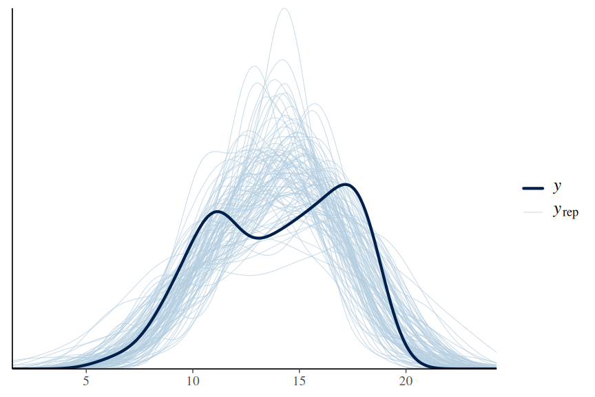

```r
freitas_brm4 |> pp_check(type = "dens_overlay", ndraws = 100)
```

## 9.3 DHARMa residuals

DHARMa residuals provide very useful diagnostics. Unfortunately, we cannot directly use the `simulateResiduals()` function to generate the simulated residuals. However, if we are willing to calculate some of the components yourself, we can still obtain the simulated residuals from the fitted stan model.

We need to supply:

- simulated (predicted) responses associated with each observation.
- observed values
- fitted (predicted) responses (averaged) associated with each observation

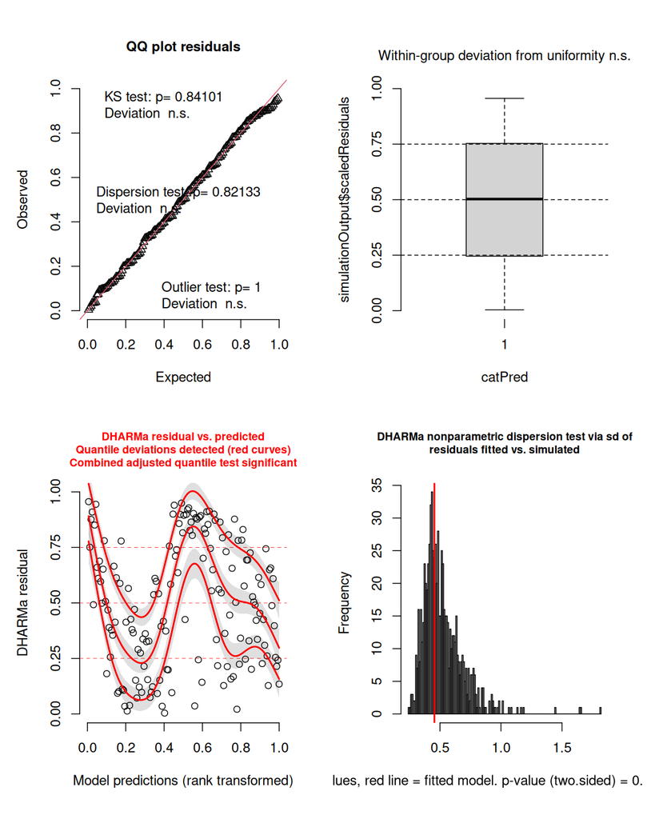

```r
freitas_resids <- make_brms_dharma_res(freitas_brm4, integerResponse = FALSE)
wrap_elements(~ testUniformity(freitas_resids)) +
  wrap_elements(~ plotResiduals(freitas_resids, form = factor(rep(1, nrow(freitas))))) +
  wrap_elements(~ plotResiduals(freitas_resids, quantreg = TRUE)) +
  wrap_elements(~ testDispersion(freitas_resids))
```

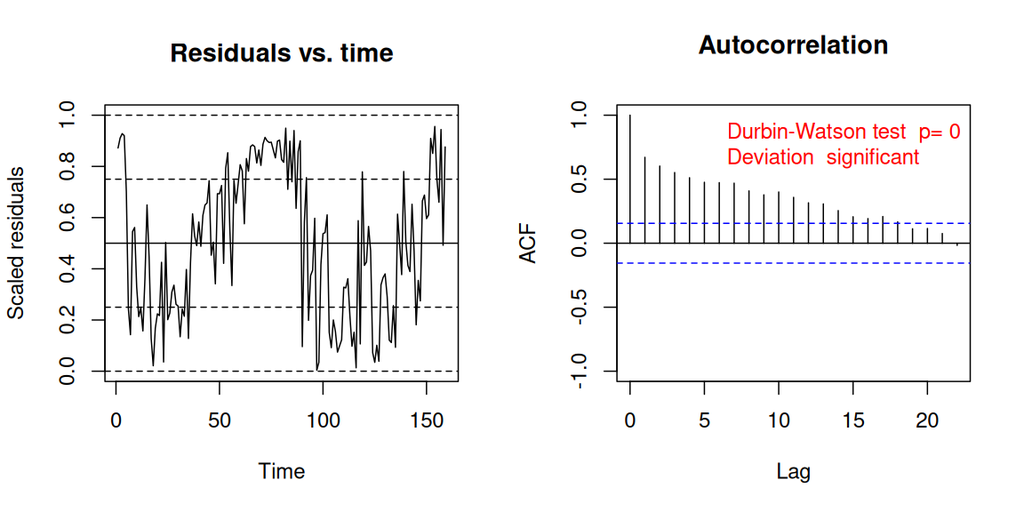

```
    Durbin-Watson test

data:  simulationOutput$scaledResiduals ~ 1
DW = 0.6368, p-value < 2.2e-16
alternative hypothesis: true autocorrelation is not 0
```

```r
freitas_resids |> testTemporalAutocorrelation(time = freitas$DAY)
```

[output not shown]

[output cut: 196 more lines]

[output not shown]

```
Using  as id variables
```

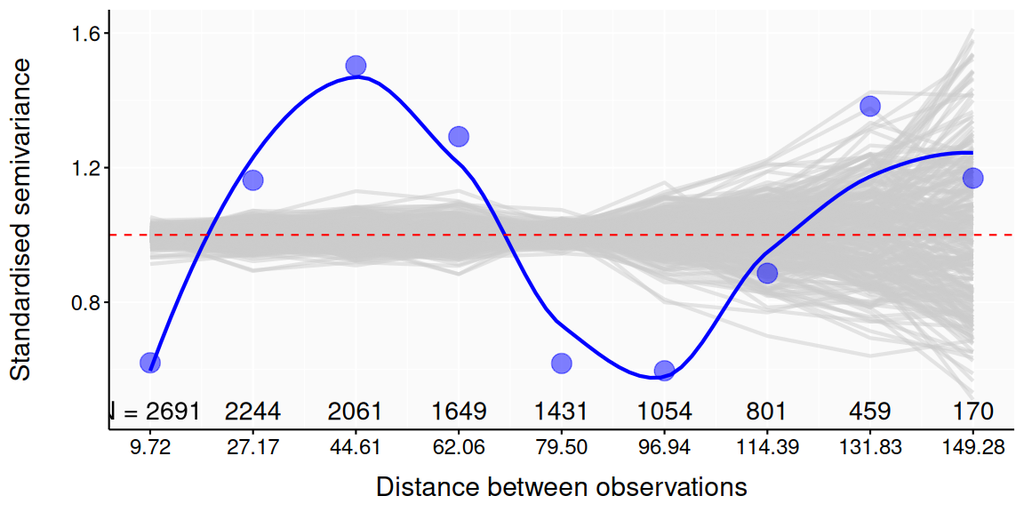

```r
autocor_check(freitas, freitas_brm3, variable = "DAY", n.sim = 250)
```

[output not shown]

[output cut: 196 more lines]

[output not shown]

```
Using  as id variables
```

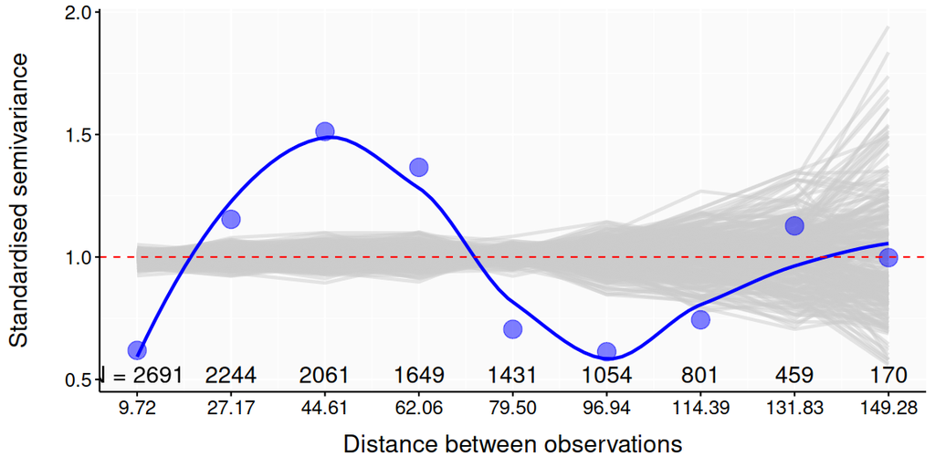

```r
autocor_check(freitas, freitas_brm4, variable = "DAY", n.sim = 250)
```

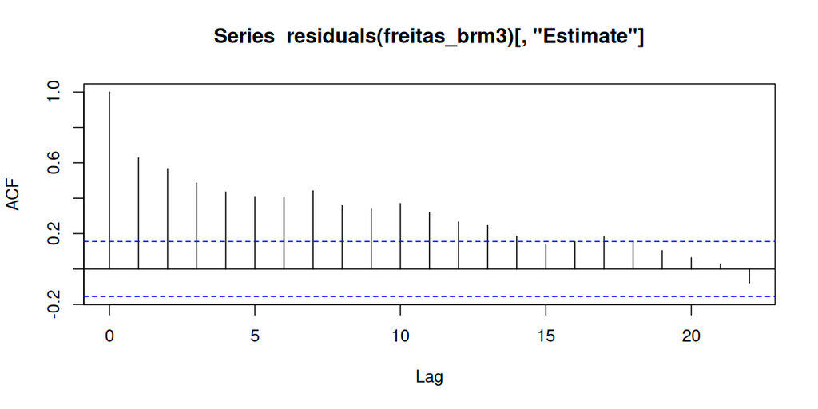

```r
residuals(freitas_brm3)[, "Estimate"] |> acf()
```

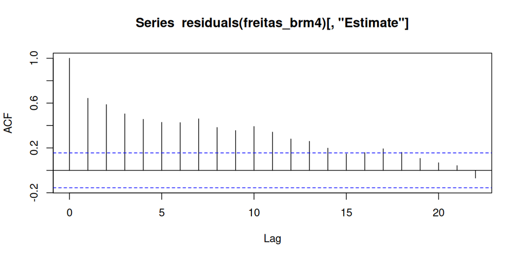

```r
residuals(freitas_brm4)[, "Estimate"] |> acf()
```

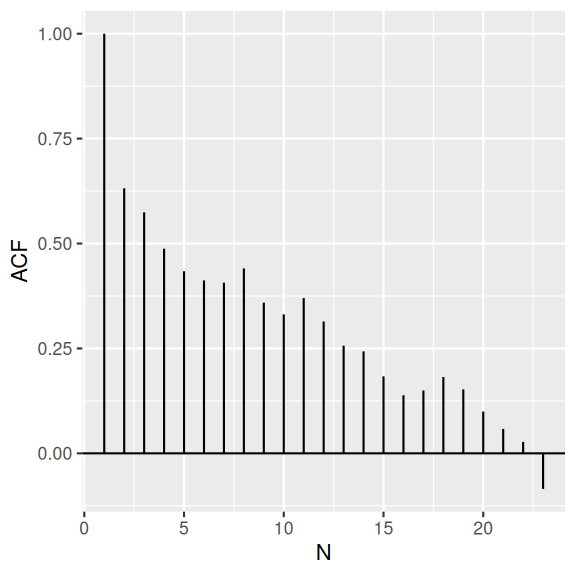

```r
freitas_brm3 |>
  augment() |>
  ## group_by(ID) |>
  reframe(ACF = as.numeric(acf(.resid, plot = FALSE)$acf)) |>
  ## group_by(ID) |>
  mutate(N = 1:n()) |>
  ## slice(1:12) |>
  ungroup() |>
  group_by(N) |>
  summarise(ACF = mean(ACF)) |>
  ggplot(aes(y = ACF, x = N)) +
  geom_hline(yintercept = 0) +
  geom_segment(aes(yend = 0, xend = N))
```

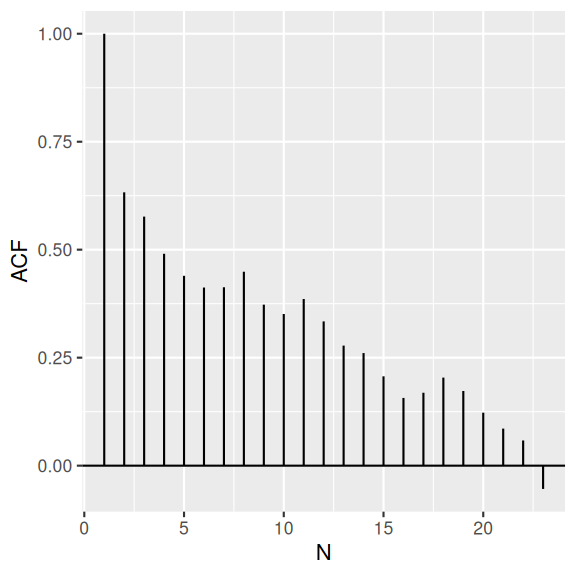

```r
freitas_brm4 |>
  augment() |>
  ## group_by(ID) |>
  reframe(ACF = as.numeric(acf(.resid, plot = FALSE)$acf)) |>
  ## group_by(ID) |>
  mutate(N = 1:n()) |>
  ## slice(1:12) |>
  ungroup() |>
  group_by(N) |>
  summarise(ACF = mean(ACF)) |>
  ggplot(aes(y = ACF, x = N)) +
  geom_hline(yintercept = 0) +
  geom_segment(aes(yend = 0, xend = N))
```

## References

Freitas, Carla, Esben M. Olsen, Halvor Knutsen, Jon Albretsen, and Even Moland. 2016. “Temperature-Associated Habitat Selection in a Cold-Water Marine Fish.” *Journal of Animal Ecology* 85 (3): 628–37. https://doi.org/https://doi.org/10.1111/1365-2656.12458.